# Clustering

## Exercise Question 2

Build a k-means clustering with n_cluster = 10. Name the model as "km". Fit the model with the data "X_prepared" using the fit_predict() function to get the label results. Name the results as "labels_km".

```python
#Type your answers for question 2 here:
#Create and name the Kmeans clustering model as "km".
km = KMeans(n_clusters=10, random_state=42)
#Fit the "km" model and name the results as "labels_km".
labels_km = km.fit_predict(X_prepared)
print(labels_km)
```

```
[2 6 3 ... 0 9 3]
```

If your answers for question 2 are correct with the right names, you should be able to run the following cell and visualize the centers for the 10 clusters.

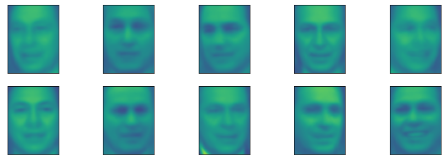

```python
fig, axes = plt.subplots(2, 5, subplot_kw={'xticks': (), 'yticks': ()},
                         figsize=(12, 4))
for center, ax in zip(km.cluster_centers_, axes.ravel()):
    ax.imshow(pca.inverse_transform(center).reshape(image_shape),
              vmin=0, vmax=1)
```

As you can tell, The cluster centers found by k-means are very smooth versions of faces. This is not very surprising, given that each center is an average of 64 to 386 face images.

## Exercise Question 3

Build a agglomerative cluster with n_clusters = 10, name the model as "agglomerative". Fit the model using fit_predict() function with "X_prepared" to get the results. Name the results as "labels_agg".

```python
#Type your answers for question 3 here:
#Create and name an agglomerative clustering model as "agglomerative".
agglomerative = AgglomerativeClustering(n_clusters=10)
#Fit the "agglomerative" model and name the results as "labels_agg".
labels_agg = agglomerative.fit_predict(X_prepared)
print(labels_agg)
```

```
[9 7 1 ... 0 0 2]
```

If your answers for question 3 arecorrect with right names, you should be able to run the following cell and create a dendrogram.

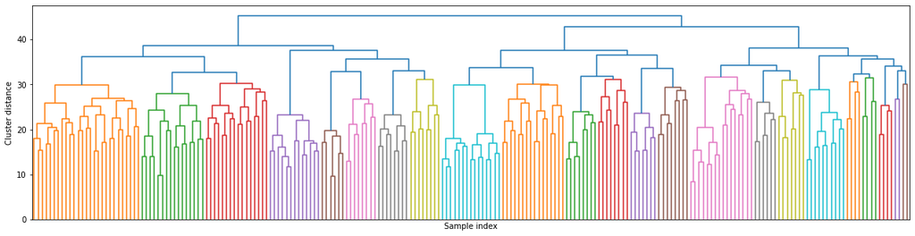

```python
from scipy.cluster.hierarchy import dendrogram, ward
linkage_array = ward(X_prepared)
# now we plot the dendrogram for the linkage_array
# containing the distances between clusters
plt.figure(figsize=(20, 5))
dendrogram(linkage_array, p=7, truncate_mode='level', no_labels=True)
plt.xlabel("Sample index")
plt.ylabel("Cluster distance")
```

Let’s visualize the 10 clusters, as we did for k-means earlier (question 2). Note that there is no notion of cluster center in agglomerative clustering, and we simply show the first couple of points in each cluster. We show the number of points in each cluster to the left of the first image:

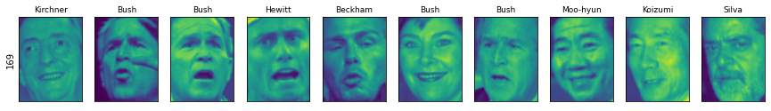

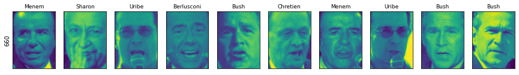

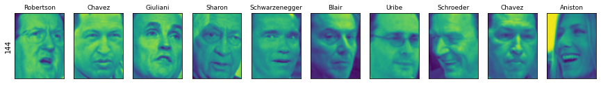

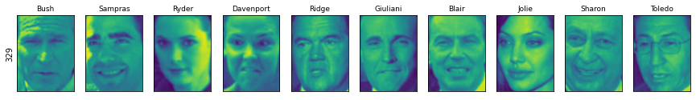

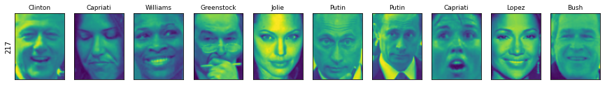

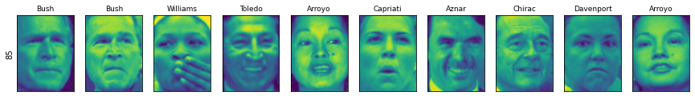

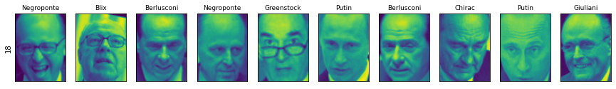

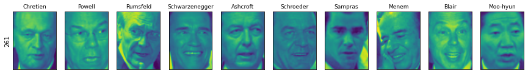

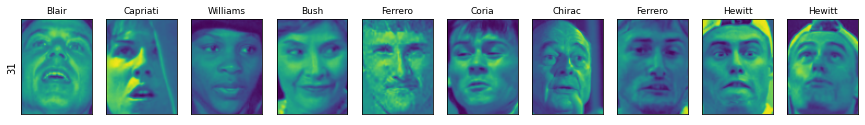

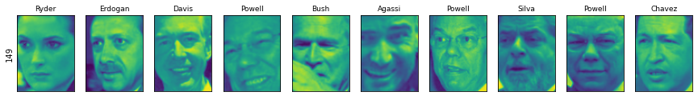

```python
n_clusters = 10
for cluster in range(n_clusters):
    mask = labels_agg == cluster
    fig, axes = plt.subplots(1, 10, subplot_kw={'xticks': (), 'yticks': ()},
                             figsize=(15, 8))
    axes[0].set_ylabel(np.sum(mask))
    for image, label, asdf, ax in zip(X_people[mask], y_people[mask],
                                      labels_agg[mask], axes):
        ax.imshow(image.reshape(image_shape), vmin=0, vmax=1)
        ax.set_title(people.target_names[label].split()[-1],
                     fontdict={'fontsize': 9})
```

## Summary

This document has shown that applying and evaluating clustering is a highly qualitative procedure, and often most helpful in the exploratory phase of data analysis. We looked at three clustering algorithms: k-means, DBSCAN, and agglomerative clustering. All three have a way of controlling the granularity of clustering. k-means and agglomerative clustering allow you to specify the number of desired clusters, while DBSCAN lets you define proximity using the eps parameter, which indirectly influences cluster size. All three methods can be used on large, real-world datasets, are relatively easy to understand, and allow for clustering into many clusters.

Each of the algorithms has somewhat different strengths. k-means allows for a characterization of the clusters using the cluster means. It can also be viewed as a decomposition method, where each data point is represented by its cluster center. DBSCAN allows for the detection of “noise points” that are not assigned any cluster, and it can help automatically determine the number of clusters. In contrast to the other two methods, it allow for complex cluster shapes, as we saw in the two_moons example. DBSCAN sometimes produces clusters of very differing size, which can be a strength or a weakness. Agglomerative clustering can provide a whole hierarchy of possible partitions of the data, which can be easily inspected via dendrograms.

# Submission

Once you finish all the excercise questions, check whether they all have outputs. Once you checked, save it as a HTML file and name it as "full name Exercise 6". Finally, submit it to Sakai.